# Protein contrasts: HR against LR

Every protein is tested in nine contrasts between the six group-by-time means (HR and LR at T1, T2 and T3), and in two F-tests that ask about the whole trajectory. The fit is limpa’s `dpcDE()`, which carries each value’s standard error into a precision weight. This step also gives the whole-proteome view: a PCA and PERMANOVA per time point.

## Packages

```r
library(here)
library(limma)
library(limpa)
library(dplyr)
library(tidyr)
library(purrr)
library(ggplot2)
source(here("00_Setup", "Shared_functions", "workbooks.R"))
inputs <- c(
  proteins = "01_Processing/02_Quantification/c_data/quantification.rds",
  corrected = "01_Processing/03_Blood_Correction/c_data/blood_correction.rds"
)
paths <- vapply(inputs, here, character(1))
stopifnot(file.exists(paths))
```

## Input

limpa’s protein values with standard errors, and the biopsy table with the blood index.

```r
proteins <- readRDS(paths[["proteins"]])
meta <- as_tibble(proteins$targets)
count(meta, group, timepoint)
```

```
# A tibble: 6 × 3
  group timepoint     n
  <chr> <chr>     <int>
1 HR    T1            8
2 HR    T2            8
3 HR    T3            8
4 LR    T1            8
5 LR    T2            8
6 LR    T3            8
```

## Design and fit

The design has one mean per group and time point (`group_time`) plus the blood index as a covariate, so every comparison is made at equal blood content. Each person gave three biopsies, so person is a block: limma estimates how alike one person’s biopsies are and uses it in every test. `sample.weights = TRUE` gives each biopsy a weight from how noisy it is, so the three thin biopsies count less in these fits without being dropped. Only `dpcDE()` fits use the weights; the PCA and PERMANOVA below, and every later method without a model, use all biopsies equally.

```r
design <- model.matrix(~ 0 + group_time + blood, meta)
colnames(design) <- sub("^group_time", "", colnames(design))
fit <- dpcDE(proteins, design, block = meta$subject, sample.weights = TRUE, plot = FALSE)
c(within_person_correlation = round(fit$correlation, 3))
```

```
within_person_correlation
                    0.178
```

## Sample weights

A weight above 1 means the biopsy fits the model better than average. The weights must not differ by group, or they would tilt the HR-against-LR comparison.

```r
sample_weights <- meta |>
  select(sample_id, subject, group, timepoint) |>
  mutate(weight = fit$targets$sample.weight)
arrange(sample_weights, weight) |> head(4)
```

```
# A tibble: 4 × 5
  sample_id subject group timepoint weight
  <chr>     <chr>   <chr> <chr>      <dbl>
1 S28_T3    HR_S28  HR    T3         0.194
2 S28_T2    HR_S28  HR    T2         0.316
3 S24_T3    HR_S24  HR    T3         0.320
4 S17_T2    LR_S17  LR    T2         0.428
```

```r
weight_test <- wilcox.test(weight ~ group, data = sample_weights, exact = FALSE)
c(median_hr = median(sample_weights$weight[sample_weights$group == "HR"]),
  median_lr = median(sample_weights$weight[sample_weights$group == "LR"]),
  wilcoxon_p = weight_test$p.value)
```

```
 median_hr  median_lr wilcoxon_p
 1.0923708  1.3118593  0.5567605
```

```r
stopifnot(weight_test$p.value > 0.05)
```

## Nine contrasts

| Contrast | Compares | Role |
| --- | --- | --- |
| `Training_HR`, `Training_LR` | T2 − T1 within the group | descriptive |
| `Acute_HR`, `Acute_LR` | T3 − T2 within the group | descriptive |
| `Baseline_HRvLR` | HR − LR at T1 | baseline reference |
| `Trained_HRvLR`, `Acute_HRvLR` | HR − LR at T2, at T3 | descriptive |
| `Training_Interaction` | HR’s training change minus LR’s | primary |
| `Acute_Interaction` | HR’s bout change minus LR’s | secondary |

The groups come from an outcome, so the T1 difference shows how far apart the split starts.

```r
contrast_matrix <- makeContrasts(
  Training_HR = HR_T2 - HR_T1, Training_LR = LR_T2 - LR_T1,
  Acute_HR = HR_T3 - HR_T2, Acute_LR = LR_T3 - LR_T2,
  Baseline_HRvLR = HR_T1 - LR_T1, Trained_HRvLR = HR_T2 - LR_T2, Acute_HRvLR = HR_T3 - LR_T3,
  Training_Interaction = (HR_T2 - HR_T1) - (LR_T2 - LR_T1),
  Acute_Interaction = (HR_T3 - HR_T2) - (LR_T3 - LR_T2),
  levels = design
)
roles <- tibble(
  contrast = colnames(contrast_matrix),
  role = case_when(
    contrast == "Training_Interaction" ~ "primary",
    contrast == "Acute_Interaction" ~ "secondary",
    contrast == "Baseline_HRvLR" ~ "baseline_reference",
    .default = "descriptive"
  )
)
eb <- eBayes(contrasts.fit(fit, contrast_matrix), robust = TRUE)
```

## Results per protein and contrast

`topTable()` gives each protein’s logFC with its 95% interval, moderated t and p; `fdr` is Benjamini-Hochberg within the contrast. Π = p^|logFC| (Xiao et al. 2014) is the nominal call: small when p is small and the fold change large; Π < 0.05 counts as a hit beside logFC, interval, p and FDR.

```r
annotation <- tibble(
  uniprot_id = rownames(proteins), gene = sub(";.*", "", proteins$genes$Genes),
  n_observed = rowSums(proteins$other$n.observations > 0)
)
results <- map(set_names(colnames(contrast_matrix)), \(contrast) {
  topTable(eb, coef = contrast, number = Inf, sort.by = "none", confint = TRUE) |>
    as_tibble() |>
    transmute(logFC, logFC_lower = CI.L, logFC_upper = CI.R, t, p = P.Value, fdr = adj.P.Val) |>
    bind_cols(annotation, x = _)
}) |>
  list_rbind(names_to = "contrast") |>
  mutate(pi_score = p^abs(logFC), sig_pi = sign(logFC) * (pi_score < 0.05))
contrast_summary <- results |>
  summarise(
    n_tested = n(), pi_up = sum(sig_pi == 1), pi_down = sum(sig_pi == -1),
    n_nominal = sum(p < 0.05), n_fdr_05 = sum(fdr < 0.05), min_fdr = min(fdr), .by = contrast
  ) |>
  left_join(roles, by = "contrast")
contrast_summary
```

```
# A tibble: 9 × 8
  contrast             n_tested pi_up pi_down n_nominal n_fdr_05 min_fdr role
  <chr>                   <int> <int>   <int>     <int>    <int>   <dbl> <chr>
1 Training_HR              2059    24      14       156        0 0.255   descri…
2 Training_LR              2059    48       3       203        1 0.00801 descri…
3 Acute_HR                 2059    54      16       155        5 0.0235  descri…
4 Acute_LR                 2059    19      65       204        0 0.258   descri…
5 Baseline_HRvLR           2059    12      13        86        0 0.0716  baseli…
6 Trained_HRvLR            2059    17      39       141        0 0.531   descri…
7 Acute_HRvLR              2059    33      14       124        0 0.388   descri…
8 Training_Interaction     2059     7      33        68        0 0.999   primary
9 Acute_Interaction        2059    66      16       119        0 0.136   second…
```

Chance alone puts about 103 proteins below p = 0.05 in each contrast.

## Trajectory F-tests

An F-test asks about several contrasts at once and returns one p per protein, with no direction. “Any difference” asks whether HR and LR differ at T1, T2 or T3; “shape” asks whether the two groups’ training and bout changes differ (both interactions). The contrasts above say where and in which direction.

```r
f_test <- \(coefs) {
  topTable(eb, coef = coefs, number = Inf, sort.by = "none") |>
    as_tibble() |>
    transmute(f = .data$F, p = P.Value, fdr = adj.P.Val) |>
    bind_cols(annotation, x = _)
}
trajectory_tests <- bind_rows(
  any_difference = f_test(c("Baseline_HRvLR", "Trained_HRvLR", "Acute_HRvLR")),
  shape = f_test(c("Training_Interaction", "Acute_Interaction")),
  .id = "test"
)
trajectory_tests |>
  summarise(n_nominal = sum(p < 0.05), n_fdr_05 = sum(fdr < 0.05), min_fdr = min(fdr), .by = test)
```

```
# A tibble: 2 × 4
  test           n_nominal n_fdr_05 min_fdr
  <chr>              <int>    <int>   <dbl>
1 any_difference        98        0   0.141
2 shape                 84        0   0.153
```

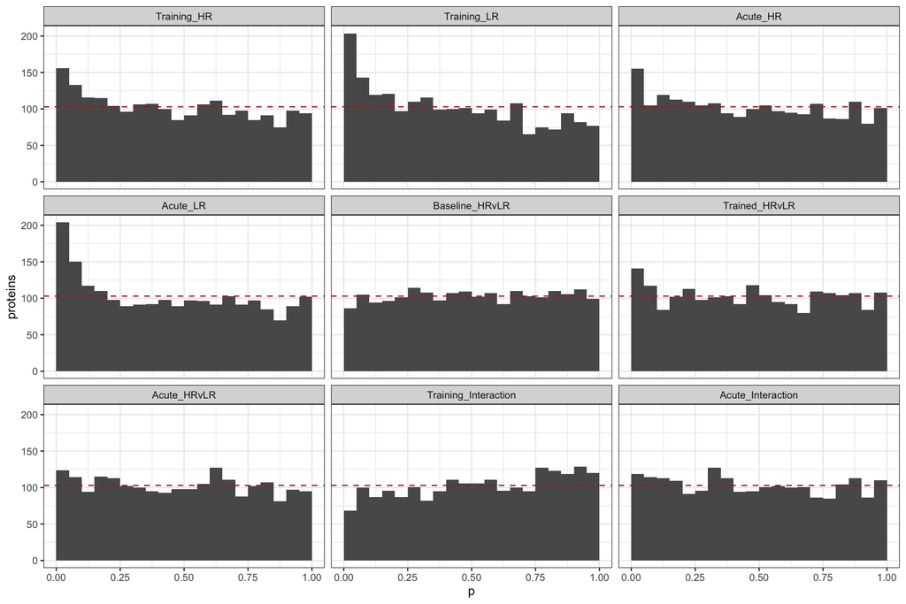

Figure 1: p values per contrast. Dashed: a flat null (tested / 20).

```r
results |>
  mutate(contrast = factor(contrast, colnames(contrast_matrix))) |>
  ggplot(aes(p)) +
  geom_histogram(binwidth = 0.05, boundary = 0, fill = "grey35") +
  geom_hline(yintercept = nrow(proteins) / 20, linetype = 2, colour = "firebrick") +
  facet_wrap(~contrast) +
  labs(x = "p", y = "proteins") +
  theme_bw(base_size = 9)
```

A spike at zero on a flat background is signal; a flat histogram is chance.

## Does one group’s response carry over to the other?

The proteins one group changes with training (or the bout) at Π < 0.05 or p < 0.05 form a set; fry (limma) tests that set in the other group’s contrast. All four sets per pairing are kept; fry tests those with 5 or more proteins. Beside each test: the set’s mean logFC in the group that chose it (inflated by the selection) and in the other group, and the share of members with the same sign. fry is a rotation test across biopsies that keeps the person block and its within-person correlation.

```r
pairings <- tribble(
  ~set_from, ~ranked_on,
  "Training_HR", "Training_LR", "Training_LR", "Training_HR",
  "Acute_HR", "Acute_LR", "Acute_LR", "Acute_HR"
)
signature <- \(contrast, criterion, direction) {
  r <- filter(results, .data$contrast == .env$contrast)
  hit <- if (criterion == "pi") r$pi_score < 0.05 else r$p < 0.05
  hit & if (direction == "up") r$logFC > 0 else r$logFC < 0
}
fry_concordance <- pmap(pairings, \(set_from, ranked_on) {
  sets <- expand_grid(criterion = c("pi", "nominal"), set_direction = c("up", "down")) |>
    mutate(
      set = paste(criterion, set_direction, sep = "_"),
      rows = map2(criterion, set_direction, \(c, d) which(signature(set_from, c, d))),
      set_size = lengths(rows), tested = set_size >= 5
    )
  tested <- filter(sets, tested)
  own <- filter(results, contrast == set_from)$logFC
  other <- filter(results, contrast == ranked_on)$logFC
  carried <- transmute(tested, set,
    mean_logfc_own = map_dbl(rows, \(i) mean(own[i])),
    mean_logfc_other = map_dbl(rows, \(i) mean(other[i])),
    same_sign_share = map_dbl(rows, \(i) mean(sign(own[i]) == sign(other[i])))
  )
  tests <- fry(fit$EList, index = set_names(tested$rows, tested$set), design = design,
    contrast = contrast_matrix[, ranked_on], block = meta$subject, correlation = fit$correlation
  ) |>
    as_tibble(rownames = "set") |>
    transmute(set, direction = Direction, p = PValue, fdr = FDR)
  sets |>
    transmute(set_from, ranked_on, set, criterion, set_direction, set_size, tested) |>
    left_join(tests, by = "set") |>
    left_join(carried, by = "set")
}) |>
  list_rbind()
fry_concordance
```

```
# A tibble: 16 × 13
   set_from    ranked_on set   criterion set_direction set_size tested direction
   <chr>       <chr>     <chr> <chr>     <chr>            <int> <lgl>  <chr>
 1 Training_HR Training… pi_up pi        up                  24 TRUE   Up
 2 Training_HR Training… pi_d… pi        down                14 TRUE   Down
 3 Training_HR Training… nomi… nominal   up                 122 TRUE   Up
 4 Training_HR Training… nomi… nominal   down                34 TRUE   Down
 5 Training_LR Training… pi_up pi        up                  48 TRUE   Up
 6 Training_LR Training… pi_d… pi        down                 3 FALSE  <NA>
 7 Training_LR Training… nomi… nominal   up                 196 TRUE   Up
 8 Training_LR Training… nomi… nominal   down                 7 TRUE   Down
 9 Acute_HR    Acute_LR  pi_up pi        up                  54 TRUE   Up
10 Acute_HR    Acute_LR  pi_d… pi        down                16 TRUE   Down
11 Acute_HR    Acute_LR  nomi… nominal   up                 106 TRUE   Up
12 Acute_HR    Acute_LR  nomi… nominal   down                49 TRUE   Down
13 Acute_LR    Acute_HR  pi_up pi        up                  19 TRUE   Up
14 Acute_LR    Acute_HR  pi_d… pi        down                65 TRUE   Down
15 Acute_LR    Acute_HR  nomi… nominal   up                  32 TRUE   Up
16 Acute_LR    Acute_HR  nomi… nominal   down               172 TRUE   Down
# ℹ 5 more variables: p <dbl>, fdr <dbl>, mean_logfc_own <dbl>,
#   mean_logfc_other <dbl>, same_sign_share <dbl>
```

## Whole-proteome structure: levels and changes

A PCA on the blood-corrected values (proteins scaled) at each time point, and on each person’s change: T2 − T1 (training) and T3 − T2 (acute bout), one point per person. PERMANOVA (vegan’s `adonis2()`, 9,999 permutations) asks how much of the distance between people group explains (R²) in each. On a level it asks whether HR and LR proteomes differ; on a change, whether they responded differently across the whole proteome, the multivariate form of the interaction. Time is also tested across all biopsies, with permutations kept inside each person; the model has no person term, so this test is conservative.

```r
corrected <- readRDS(paths[["corrected"]])
people <- distinct(meta, subject, group)
at_time <- \(tp) {
  rows <- meta$timepoint == tp
  set_names(as.data.frame(corrected$E[, rows]), meta$subject[rows])[, people$subject]
}
# A protein with no spread in a window (one modelled value for everyone) cannot be scaled; it is
# left out of that window.
spread_only <- \(x) x[, apply(x, 2, sd) > 0]
structure_data <- list(
  T1 = at_time("T1"), T2 = at_time("T2"), T3 = at_time("T3"),
  Training = at_time("T2") - at_time("T1"), Acute = at_time("T3") - at_time("T2")
) |>
  map(\(x) scale(spread_only(t(as.matrix(x)))))
map_int(structure_data, ncol)
```

```
      T1       T2       T3 Training    Acute
    2056     2057     2054     2058     2059
```

```r
pca <- imap(structure_data, \(x, window) {
  fit <- prcomp(x)
  as_tibble(fit$x[, 1:2], rownames = "subject") |>
    mutate(
      pc1_share = summary(fit)$importance[2, 1], pc2_share = summary(fit)$importance[2, 2]
    )
}) |>
  list_rbind(names_to = "window") |>
  left_join(people, by = "subject")
permanova_group <- \(x) {
  set.seed(1)
  fit <- vegan::adonis2(
    dist(x) ~ group,
    data = people[match(rownames(x), people$subject), ],
    permutations = permute::how(nperm = 9999)
  )
  tibble(n_samples = nrow(x), r2 = fit$R2[1], f = fit$F[1], p = fit$`Pr(>F)`[1])
}
set.seed(1)
time_fit <- vegan::adonis2(
  dist(scale(t(corrected$E))) ~ timepoint,
  data = meta, permutations = permute::how(nperm = 9999, blocks = factor(meta$subject))
)
permanova_tests <- bind_rows(
  map(structure_data, permanova_group) |>
    list_rbind(names_to = "window") |>
    mutate(term = "group", .before = 1),
  tibble(
    term = "time", window = "all", n_samples = nrow(meta), r2 = time_fit$R2[1],
    f = time_fit$F[1], p = time_fit$`Pr(>F)`[1]
  )
)
permanova_tests
```

```
# A tibble: 6 × 6
  term  window   n_samples     r2     f      p
  <chr> <chr>        <int>  <dbl> <dbl>  <dbl>
1 group T1              16 0.0559 0.828 0.847
2 group T2              16 0.0728 1.10  0.280
3 group T3              16 0.0715 1.08  0.293
4 group Training        16 0.0609 0.908 0.613
5 group Acute           16 0.0795 1.21  0.166
6 time  all             48 0.0534 1.27  0.0085
```

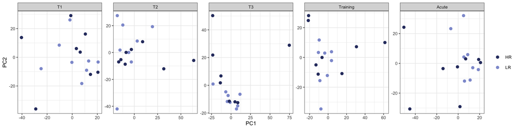

Figure 2: People on PC1 and PC2 of the blood-corrected values: per time point and per change.

```r
ggplot(pca, aes(PC1, PC2, colour = group)) +
  geom_point(size = 2) +
  facet_wrap(~ factor(window, names(structure_data)), scales = "free", nrow = 1) +
  scale_colour_manual(values = c(HR = "#2E3A6E", LR = "#8E9BD3"), name = NULL) +
  theme_bw(base_size = 9)
```

## Validation

```r
stopifnot(
  nrow(results) == nrow(proteins) * ncol(contrast_matrix), !anyNA(results$p),
  all(results$fdr >= results$p),
  all(results$logFC_lower <= results$logFC & results$logFC <= results$logFC_upper),
  nrow(trajectory_tests) == 2 * nrow(proteins),
  nrow(fry_concordance) == 4 * nrow(pairings),
  all(fry_concordance$tested == !is.na(fry_concordance$p))
)
```

## Summary

2059 proteins in nine contrasts: 6 calls at BH < 0.05 in all, and between 68 and 204 at p < 0.05 per contrast against about 103 by chance. Group explains 5.6%, 7.3% and 7.2% of the distance between people at T1, T2 and T3.

## Save

`protein_contrasts.rds` holds the fit, the moderated contrasts, the design and contrast matrix; later steps read it.

```r
out <- here("02_HRvLR", "01_Protein_Contrasts", "c_data")
dir.create(out, showWarnings = FALSE)
saveRDS(
  list(fit = fit, eb = eb, design = design, contrast_matrix = contrast_matrix),
  file.path(out, "protein_contrasts.rds")
)
write_workbook(
  list(
    protein_by_contrast = arrange(results, match(contrast, colnames(contrast_matrix)), p),
    contrast_summary = contrast_summary,
    trajectory_tests = arrange(trajectory_tests, test, p),
    sample_weights = sample_weights,
    fry_concordance = fry_concordance,
    pca = pca,
    permanova = permanova_tests
  ),
  c(
    "Per contrast and protein: logFC with 95% CI, t, p, FDR (BH within contrast), Π, the Π call.",
    "Per contrast: tested, Π up and down, p < 0.05 and BH < 0.05 counts, lowest FDR, role.",
    "Per protein: moderated F for any HR-LR difference and trajectory shape; FDR (BH) within test.",
    "Per biopsy: limpa sample weight; tested HR against LR.",
    "fry: each group's responders tested in the other group's contrast; FDR within each pairing.",
    "PC1 and PC2 per person at each time point and per change (training, acute), proteins scaled.",
    "PERMANOVA: group at each time point; time across all biopsies within person."
  ),
  file.path(out, "protein_contrasts.xlsx"), inputs, paths
)
```